# Optimize mini-batching

The enhancement for SAGA performance from mini-batching depends on two things. Firstly, mini-batching is expected to benefit from the efficiency of vectorized computation, which reduces the cost of a single epoch. Secondly, while the total complexity of SAGA decreases linearly in batch size up to a certain value, emperical study also shows that the complexity explodes with values greater than an optimal mini-batch size (Gazagnadou, Gower and Salmon 2019). Therefore, we expect a batch size at the optimal point with vectorized computation to bring us the best performance enhancement.

## Optimal batch size and step size for ridge

Rather than the SAGA step $\eta = \frac{1}{3(\mu n + L_{max})}$,

$$\begin{align}
b^* &= \left \lfloor 1 + \frac{\mu (n-1)}{4 (\overline{L} + \lambda)} \right \rfloor \\
\eta^* &= \frac{1}{4} \frac{1}{max \Big \{ \mathcal{L}(b^*) + \lambda, \frac{1}{b^*} \frac{n-b^*}{n-1} L_{max} + \frac{\mu n}{4 b} \Big \}} \\
\mathcal{L}(b^*) &= \frac{n(b^* - 1)}{b^*(n-1)} L + \frac{n - b^*}{b^*(n-1)} L_{max}
\end{align}$$

where the ridge strength $\lambda$ has been added to every smoothness constant, and the mean smoothness constant $\overline{L}$ is replaced by the largest eigenvalue of $\mathbf{X}^T \mathbf{X}$ if it is significantly larger than the rest.

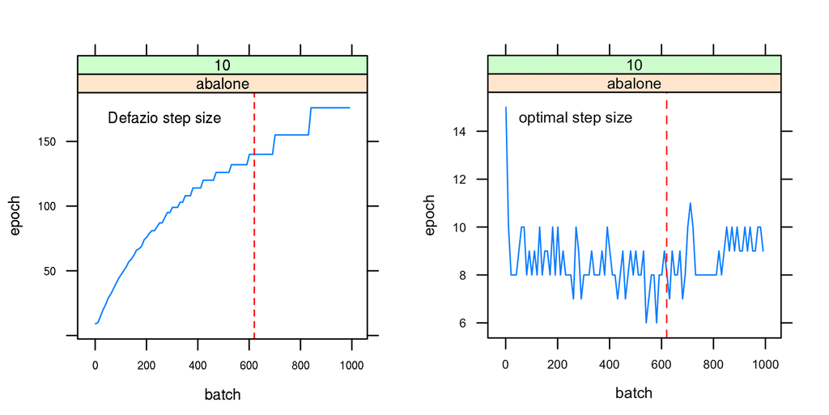

Step size

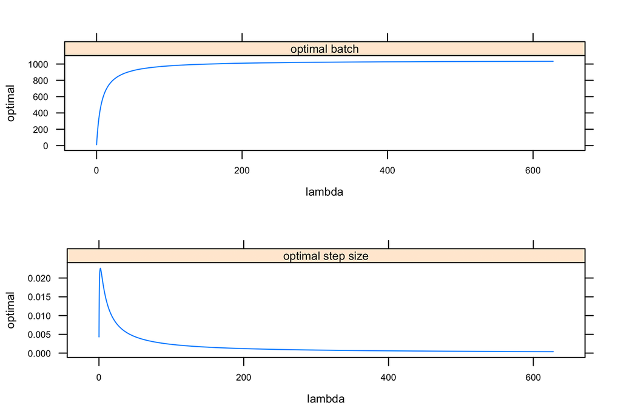

Abalone

## Benchmark

The benchmark [Sript] was run on [Cedar of Canada Compute](https://docs.computecanada.ca/wiki/Cedar), it is a comparison of the returned epoch loss of each run by setting `options(sgdnet.debug = TRUE)`. These datasets is publicly accessible, they are the testing set of YearPredictionMSD, scaled version of covtype.binary, ijcnn1 from LIBSVM and unscaled version of [slice](https://archive.ics.uci.edu/ml/datasets/Relative+location+of+CT+slices+on+axial+axis) from UCI.

.

| Name | Observations | Features |
| --- | --- | --- |
| YearPredictionMSD_test | 5,1630 | 90 |
| slice_unscale | 5,3500 | 384 |

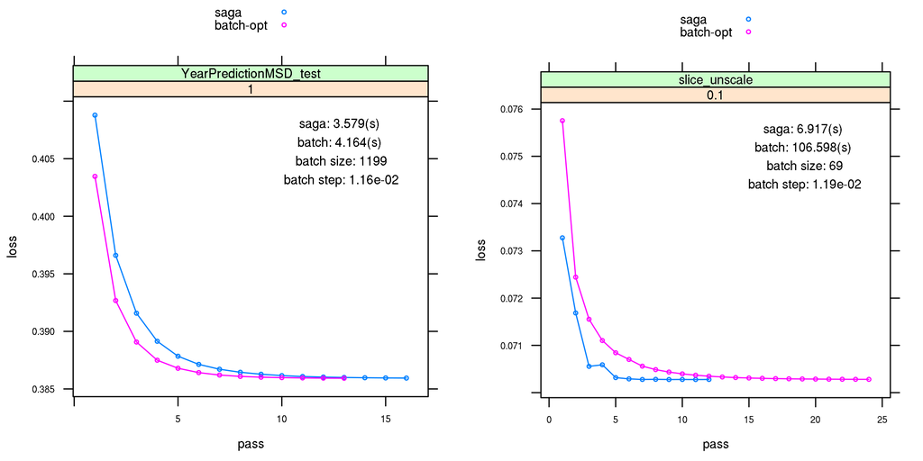

Gaussian data with ridge

| Name | Observations | Features |
| --- | --- | --- |
| ijcnn1_full | 14,1691 | 22 |
| covtype_binary_scale | 58,1012 | 54 |

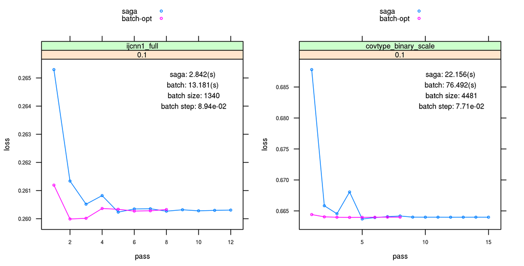

Binomial data with ridge

With optimal batch size and step size, mini-batch could converge with less epoch for most examples. Futrue work based on Eigen 3.4’s functionality to get a view into submatrix by indexing with a vector of indices.